# Exercise 3

## Exercise 2.

Names and description of the variables.

```r
glimpse(alc)
```

```
## Observations: 382
## Variables: 35
## $ school     <fct> GP, GP, GP, GP, GP, GP, GP, GP, GP, GP, GP, GP, GP,...
## $ sex        <fct> F, F, F, F, F, M, M, F, M, M, F, F, M, M, M, F, F, ...
## $ age        <int> 18, 17, 15, 15, 16, 16, 16, 17, 15, 15, 15, 15, 15,...
## $ address    <fct> U, U, U, U, U, U, U, U, U, U, U, U, U, U, U, U, U, ...
## $ famsize    <fct> GT3, GT3, LE3, GT3, GT3, LE3, LE3, GT3, LE3, GT3, G...
## $ Pstatus    <fct> A, T, T, T, T, T, T, A, A, T, T, T, T, T, A, T, T, ...
## $ Medu       <int> 4, 1, 1, 4, 3, 4, 2, 4, 3, 3, 4, 2, 4, 4, 2, 4, 4, ...
## $ Fedu       <int> 4, 1, 1, 2, 3, 3, 2, 4, 2, 4, 4, 1, 4, 3, 2, 4, 4, ...
## $ Mjob       <fct> at_home, at_home, at_home, health, other, services,...
## $ Fjob       <fct> teacher, other, other, services, other, other, othe...
## $ reason     <fct> course, course, other, home, home, reputation, home...
## $ nursery    <fct> yes, no, yes, yes, yes, yes, yes, yes, yes, yes, ye...
## $ internet   <fct> no, yes, yes, yes, no, yes, yes, no, yes, yes, yes,...
```

[output cut: 22 more lines]

```r
summary(alc)
```

```
##  school   sex          age        address famsize   Pstatus
##  GP:342   F:198   Min.   :15.00   R: 81   GT3:278   A: 38
##  MS: 40   M:184   1st Qu.:16.00   U:301   LE3:104   T:344
##                   Median :17.00
##                   Mean   :16.59
##                   3rd Qu.:17.00
##                   Max.   :22.00
##       Medu            Fedu             Mjob           Fjob
##  Min.   :0.000   Min.   :0.000   at_home : 53   at_home : 16
##  1st Qu.:2.000   1st Qu.:2.000   health  : 33   health  : 17
##  Median :3.000   Median :3.000   other   :138   other   :211
##  Mean   :2.806   Mean   :2.565   services: 96   services:107
##  3rd Qu.:4.000   3rd Qu.:4.000   teacher : 62   teacher : 31
##  Max.   :4.000   Max.   :4.000
##         reason    nursery   internet    guardian     traveltime
##  course    :140   no : 72   no : 58   father: 91   Min.   :1.000
##  home      :110   yes:310   yes:324   mother:275   1st Qu.:1.000
##  other     : 34                       other : 16   Median :1.000
##  reputation: 98                                    Mean   :1.442
##                                                    3rd Qu.:2.000
##                                                    Max.   :4.000
##    studytime        failures      schoolsup famsup     paid     activities
##  Min.   :1.000   Min.   :0.0000   no :331   no :144   no :205   no :181
##  1st Qu.:1.000   1st Qu.:0.0000   yes: 51   yes:238   yes:177   yes:201
##  Median :2.000   Median :0.0000
##  Mean   :2.034   Mean   :0.2906
##  3rd Qu.:2.000   3rd Qu.:0.0000
##  Max.   :4.000   Max.   :3.0000
##  higher    romantic      famrel        freetime         goout
##  no : 18   no :261   Min.   :1.00   Min.   :1.000   Min.   :1.000
##  yes:364   yes:121   1st Qu.:4.00   1st Qu.:3.000   1st Qu.:2.000
##                      Median :4.00   Median :3.000   Median :3.000
##                      Mean   :3.94   Mean   :3.223   Mean   :3.113
##                      3rd Qu.:5.00   3rd Qu.:4.000   3rd Qu.:4.000
##                      Max.   :5.00   Max.   :5.000   Max.   :5.000
##       Dalc            Walc          health         absences
##  Min.   :1.000   Min.   :1.00   Min.   :1.000   Min.   : 0.000
##  1st Qu.:1.000   1st Qu.:1.00   1st Qu.:3.000   1st Qu.: 0.000
##  Median :1.000   Median :2.00   Median :4.000   Median : 3.000
##  Mean   :1.474   Mean   :2.28   Mean   :3.579   Mean   : 5.319
##  3rd Qu.:2.000   3rd Qu.:3.00   3rd Qu.:5.000   3rd Qu.: 8.000
##  Max.   :5.000   Max.   :5.00   Max.   :5.000   Max.   :75.000
##        G1              G2              G3           alc_use
##  Min.   : 3.00   Min.   : 0.00   Min.   : 0.00   Min.   :1.000
##  1st Qu.: 8.00   1st Qu.: 8.25   1st Qu.: 8.00   1st Qu.:1.000
##  Median :10.50   Median :11.00   Median :11.00   Median :1.500
##  Mean   :10.86   Mean   :10.71   Mean   :10.39   Mean   :1.877
##  3rd Qu.:13.00   3rd Qu.:13.00   3rd Qu.:14.00   3rd Qu.:2.500
##  Max.   :19.00   Max.   :19.00   Max.   :20.00   Max.   :5.000
##   high_use
##  Mode :logical
##  FALSE:270
##  TRUE :112
##
##
##
```

## Exercise 3.

The chosen variables are:

sex - student’s sex (binary: ‘F’ - female or ‘M’ - male) higher - wants to take higher education (binary: yes or no) failures - number of past class failures (numeric: n if 1<=n<3, else 4) G3 - final grade (numeric: from 0 to 20, output target)

Hypothesises: There are more male high users than females.  
Those who want to get a higher education drink less. Alcohol abuse affects the likelihood of passing the class. G3 is lower among high users.

## Exercise 4.

Numerically and graphically explore the distributions of your chosen variables and their relationships with alcohol consumption (use for example cross-tabulations, bar plots and box plots). Comment on your findings and compare the results of your exploration to your previously stated hypotheses. The factors sex, goals,failures and will to get a high education has been individually compared to alcohol consumption with cross-tabulations. The relation between alcohol consumption and final grade number has been analyzed with the help of box plots.

```r
table(high_use=alc$high_use,sex=alc$sex) %>% prop.table %>% addmargins
```

```
##         sex
## high_use         F         M       Sum
##    FALSE 0.4109948 0.2958115 0.7068063
##    TRUE  0.1073298 0.1858639 0.2931937
##    Sum   0.5183246 0.4816754 1.0000000
```

```r
table(high_use=alc$high_use,higher_education=alc$higher) %>% prop.table %>% addmargins
```

```
##         higher_education
## high_use         no        yes        Sum
##    FALSE 0.02356021 0.68324607 0.70680628
##    TRUE  0.02356021 0.26963351 0.29319372
##    Sum   0.04712042 0.95287958 1.00000000
```

```r
table(failures=alc$failures,high_use=alc$high_use) %>% prop.table %>% addmargins
```

```
##         high_use
## failures      FALSE       TRUE        Sum
##      0   0.61256545 0.21465969 0.82722513
##      1   0.05759162 0.04188482 0.09947644
##      2   0.01308901 0.01570681 0.02879581
##      3   0.02356021 0.02094241 0.04450262
##      Sum 0.70680628 0.29319372 1.00000000
```

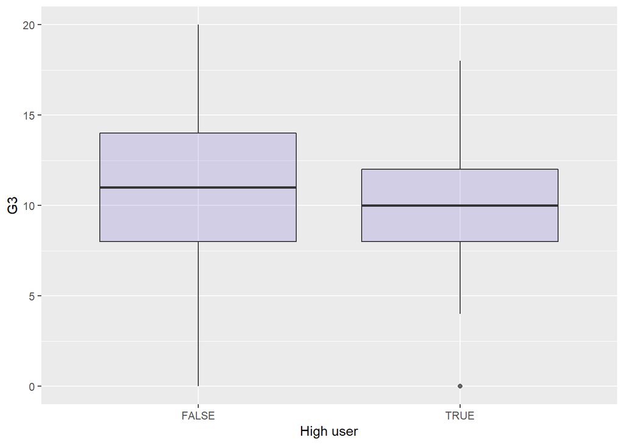

```r
# library
library(ggplot2)
# A really basic boxplot.
ggplot(alc, aes(x=as.factor(high_use), y=G3)) +
    geom_boxplot(fill="slateblue", alpha=0.2) +
    xlab("High user")
```

## Exercise 5.

The relationships between the previous variables explained with logistical regression.

```r
m <- glm(high_use ~ sex+failures + higher+G3, data = alc, family = "binomial")

summary(m)
```

```
##
## Call:
## glm(formula = high_use ~ sex + failures + higher + G3, family = "binomial",
##     data = alc)
##
## Deviance Residuals:
##     Min       1Q   Median       3Q      Max
## -1.4914  -0.9300  -0.6459   1.2744   1.8300
##
## Coefficients:
##               Estimate Std. Error z value Pr(>|z|)
## (Intercept) -1.2908447  0.6254954  -2.064 0.039045 *
## sexM         0.8517152  0.2403418   3.544 0.000394 ***
## failures     0.3841343  0.1700490   2.259 0.023886 *
## higheryes   -0.1626371  0.5565014  -0.292 0.770096
## G3          -0.0007908  0.0274334  -0.029 0.977004
## ---
## Signif. codes:  0 '***' 0.001 '**' 0.01 '*' 0.05 '.' 0.1 ' ' 1
##
## (Dispersion parameter for binomial family taken to be 1)
##
##     Null deviance: 462.21  on 381  degrees of freedom
## Residual deviance: 439.87  on 377  degrees of freedom
## AIC: 449.87
##
## Number of Fisher Scoring iterations: 4
```

```r
#OR:t
cbind(exp(coef(m)),exp(confint(m)))
```

```
##                            2.5 %    97.5 %
## (Intercept) 0.2750384 0.07761864 0.9232856
## sexM        2.3436632 1.46960406 3.7770854
## failures    1.4683426 1.05195502 2.0582424
## higheryes   0.8498996 0.28578444 2.5964534
## G3          0.9992095 0.94724459 1.0551271
```

Males posess a ~2.3 times higher risk of being high users compared to the females. The sex and the number of failures in class are related to high alcohol consumptio, the others are not.

## Exercise 6.

Provide a 2x2 cross tabulation between the variables with a statistical relationship with high/low alcohol consumption.

```r
# predict() the probability of high_use
probabilities <- predict(m, type = "response")

# add the predicted probabilities to 'alc'
alc <- mutate(alc, probability = probabilities)
alc <- mutate(alc, prediction = probability > 0.5)
```

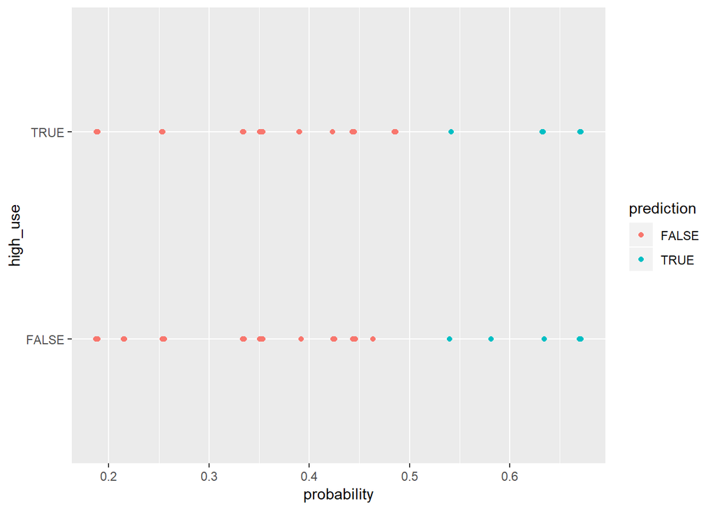

```r
g <- ggplot(alc, aes(x = probability, y = high_use,col = prediction))
g+geom_point()
```

```r
# tabulate the target variable versus the predictions
table(high_use = alc$high_use, prediction = alc$prediction) %>% prop.table %>% addmargins
```

```
##         prediction
## high_use      FALSE       TRUE        Sum
##    FALSE 0.68848168 0.01832461 0.70680628
##    TRUE  0.27486911 0.01832461 0.29319372
##    Sum   0.96335079 0.03664921 1.00000000
```

This model predicts more of not high users than high users which means it’s not reliably accurate.